# Pertemuan 3 - Regresi dengan Peubah Lag

Keira Gisella

## 1. Persiapan Data

### *Packages*

```r
library(dLagM)
library(dynlm)
library(MLmetrics)
library(lmtest)
library(car)
```

### Impor & Pembagian Data

```r
# Impor Data
data <- Import("NewDelhi_Air_quality.csv")
View(data)

n <- nrow(data)
n_train <- floor(0.8 * n)

train <- data[1:n_train, ]
test  <- data[(n_train + 1):n, ]

train.ts <- ts(train)
test.ts  <- ts(test)
data.ts  <- ts(data)
```

## Model Koyck

### Pemodelan

```r
model.koyck <- koyckDlm(x = train$so2, y = train$AQI)
summary(model.koyck)
```

```
##
## Call:
## "Y ~ (Intercept) + Y.1 + X.t"
##
## Residuals:
##      Min       1Q   Median       3Q      Max
## -2.03389 -0.64933  0.06714  0.59821  2.27449
##
## Coefficients:
##             Estimate Std. Error t value Pr(>|t|)
## (Intercept)  2.65074    3.25695   0.814    0.419
## Y.1          0.89806    0.07378  12.171   <2e-16 ***
## X.t          0.09810    4.59272   0.021    0.983
## ---
## Signif. codes:  0 '***' 0.001 '**' 0.01 '*' 0.05 '.' 0.1 ' ' 1
##
## Residual standard error: 0.9316 on 53 degrees of freedom
## Multiple R-Squared: 0.8176,  Adjusted R-squared: 0.8108
## Wald test: 118.9 on 2 and 53 DF,  p-value: < 2.2e-16
##
## Diagnostic tests:
## NULL
##
##                             alpha       beta       phi
## Geometric coefficients:  26.00265 0.09809751 0.8980589
```

**Interpretasi**: Berdasarkan hasil nilai $p_{value}$ dari peubah AQI pada 1 periode sebelumnya $AQI_{t-1}<\alpha=0.05$, artinya peubah tersebut berpengaruh signifikan terhadap AQI pada saat ini $AQI_t$. Sedangkan, nilai $p_{value}$ dari peubah $SO_2$ $(X_t)$ pada saat ini $X_t>\alpha=0.05$, yang artinya peubah $SO_2$ pada saat ini $(X_t)$ tidak berpengaruh signifikan terhadap AQI saat ini $(Y_t)$. Koefisien pada $Y_{t-1}$ mewakili parameter $\lambda$ (tingkat penurunan pengaruh).

**Persamaan:**
$$\hat{AQI_t}=2.6507+0.0981SO2_t+0.8980AQI_{t-1}$$

### Peramalan

```r
# Meramalkan 5 periode ke depan
fore.koyck <- forecast(model = model.koyck, x = test$so2, h = length(test$AQI))
fore.koyck
```

```
## $forecasts
##  [1] 25.14424 25.27523 25.39397 25.50060 25.59600 25.68058 25.75470 25.82018
##  [9] 25.87861 25.93036 25.97610 26.01645 26.05195 26.08347 26.11141
##
## $call
## forecast.koyckDlm(model = model.koyck, x = test$so2, h = length(test$AQI))
##
## attr(,"class")
## [1] "forecast.koyckDlm" "dLagM"
```

```r
# Cek Akurasi (MAPE) pada data testing
mape.koyck <- MAPE(fore.koyck$forecasts, test$AQI)
cat("MAPE Model Koyck:", mape.koyck, "\n")
```

```
## MAPE Model Koyck: 0.185176
```

## DLM

### Pemodelan (Lag=2)

```r
model.dlm <- dlm(x = train$so2, y = train$AQI, q = 2)
summary(model.dlm)
```

```
##
## Call:
## lm(formula = model.formula, data = design)
##
## Residuals:
##    Min     1Q Median     3Q    Max
## -2.365 -1.269 -0.185  1.169  3.879
##
## Coefficients:
##             Estimate Std. Error t value Pr(>|t|)
## (Intercept)   40.943      2.632  15.556  < 2e-16 ***
## x.t          -80.616     24.594  -3.278  0.00189 **
## x.1           74.553     42.562   1.752  0.08585 .
## x.2          -33.552     24.373  -1.377  0.17465
## ---
## Signif. codes:  0 '***' 0.001 '**' 0.01 '*' 0.05 '.' 0.1 ' ' 1
##
## Residual standard error: 1.683 on 51 degrees of freedom
## Multiple R-squared:  0.4248, Adjusted R-squared:  0.3909
## F-statistic: 12.55 on 3 and 51 DF,  p-value: 2.903e-06
##
## AIC and BIC values for the model:
##        AIC      BIC
## 1 219.1898 229.2265
```

### Penentuan *Lag* Optimum

```r
finiteDLMauto(formula = AQI ~ so2,
              data = data.frame(train), q.min = 1, q.max = 10,
              model.type = "dlm", error.type = "AIC", trace = TRUE)
```

```
##    q - k    MASE      AIC      BIC    GMRAE    MBRAE R.Adj.Sq    Ljung-Box
## 10    10 2.23685 195.6103 219.6622 92138.42  0.58903  0.33152 4.347288e-10
## 9      9 2.17988 198.2060 220.6604 71037.91 -0.28974  0.36439 1.436402e-10
## 8      8 2.21314 200.9399 221.7499 59984.39  0.96495  0.41023 2.080732e-10
## 7      7 2.20158 204.4604 223.5806 46100.62 -0.90581  0.42060 2.454251e-10
## 6      6 2.12237 207.5848 224.9712 36899.79  1.76981  0.41238 1.826798e-10
## 5      5 2.21755 212.3200 227.9299 45672.14  1.36747  0.38492 1.912120e-10
## 4      4 2.30630 215.7372 229.5292 60526.82  1.30069  0.37244 1.265744e-10
## 3      3 2.28688 218.2013 230.1352 48281.44  1.90862  0.37911 4.126000e-11
## 2      2 2.20700 219.1898 229.2265 41976.46  1.53537  0.39093 3.713285e-11
## 1      1 2.16877 226.2367 234.3381 29785.18  0.68051  0.33548 1.111534e-10
```

**Interpretasi:** Pilih baris dengan nilai AIC paling kecil. Di sini lag optimum berada pada $q=10$

### Pemodelan dengan lag optimum (q=10)

```r
model.dlm.opt <- dlm(x = train$so2, y = train$AQI, q = 10)
summary(model.dlm.opt)
```

```
##
## Call:
## lm(formula = model.formula, data = design)
##
## Residuals:
##    Min     1Q Median     3Q    Max
## -2.733 -1.134 -0.292  1.194  3.212
##
## Coefficients:
##             Estimate Std. Error t value Pr(>|t|)
## (Intercept)   42.819      3.634  11.784 9.78e-14 ***
## x.t          -68.093     46.375  -1.468    0.151
## x.1           26.607    109.715   0.243    0.810
## x.2            1.856    131.369   0.014    0.989
## x.3           36.987    125.117   0.296    0.769
## x.4          -93.596    122.052  -0.767    0.448
## x.5          112.392    124.859   0.900    0.374
## x.6          -60.505    128.703  -0.470    0.641
## x.7           21.782    132.729   0.164    0.871
## x.8          -47.189    133.195  -0.354    0.725
## x.9           76.709    105.166   0.729    0.471
## x.10         -51.444     42.729  -1.204    0.237
## ---
## Signif. codes:  0 '***' 0.001 '**' 0.01 '*' 0.05 '.' 0.1 ' ' 1
##
## Residual standard error: 1.704 on 35 degrees of freedom
## Multiple R-squared:  0.4914, Adjusted R-squared:  0.3315
## F-statistic: 3.074 on 11 and 35 DF,  p-value: 0.005561
##
## AIC and BIC values for the model:
##        AIC      BIC
## 1 195.6103 219.6622
```

### Peramalan Model Optimum

```r
fore.dlm.opt <- forecast(model = model.dlm.opt, x = test$so2, h = 15)
mape.dlm.opt <- MAPE(fore.dlm.opt$forecasts, test$AQI)
cat("MAPE Model DLM Optimum:", mape.dlm.opt, "\n")
```

```
## MAPE Model DLM Optimum: 0.142517
```

**Interpretasi:** Penggunaan lag optimum dalam model $q=10$, tidak ada satupun koefisien lag x.1 sampai x.10 yang signifikan secara individual. Meski begitu, model tetap signifikan secara keseluruhan (F-test, $p_{value}=0.005561<\alpha=0.05$), dan nilai AIC turun dari 219.19 (saat $q=2$) menjadi 195.61 (saat $q=10$), menandakan model dengan q=10 lebih baik dari sisi goodness of fit.Selain itu, $R^2=42.48\%$ untuk *lag=2*, sedangkan $R^2=49.14\%$ untuk *lag=10*

## ARDL

### Pemodelan

```r
model.ardl <- ardlDlm(formula = AQI ~ so2, data = train, p = 1, q = 1)
summary(model.ardl)
```

```
##
## Time series regression with "ts" data:
## Start = 2, End = 57
##
## Call:
## dynlm(formula = as.formula(model.text), data = data)
##
## Residuals:
##      Min       1Q   Median       3Q      Max
## -2.12580 -0.47135 -0.01816  0.44417  2.13895
##
## Coefficients:
##              Estimate Std. Error t value Pr(>|t|)
## (Intercept)   5.35882    2.64653   2.025 0.048032 *
## so2.t       -27.34659    7.08504  -3.860 0.000315 ***
## so2.1        23.56750    7.02280   3.356 0.001484 **
## AQI.1         0.84866    0.06269  13.538  < 2e-16 ***
## ---
## Signif. codes:  0 '***' 0.001 '**' 0.01 '*' 0.05 '.' 0.1 ' ' 1
##
## Residual standard error: 0.8285 on 52 degrees of freedom
## Multiple R-squared:  0.8585, Adjusted R-squared:  0.8503
## F-statistic: 105.1 on 3 and 52 DF,  p-value: < 2.2e-16
```

**Model yang dihasilkan:**
$$AQI_t=5.3588-27.3466SO2_t+23.5675SO2_{t-1}+0.8487AQI_{t-1}$$
Dengan $R^2=0.8585$ artinya model ini mampu menjelaskan sekitar $85,85\%$ variasi AQI. Nilai $R^2$nya termasuk sangat baik.

### *Lag* Optimum ARDL

```r
model.ardl.opt <- ardlBoundOrders(data = data.frame(data), ic = "AIC", formula = AQI ~ so2)

# Menarik kombinasi lag dengan AIC terkecil
min_p <- c()
for(i in 1:6){
  min_p[i] <- min(model.ardl.opt$Stat.table[[i]])
}
q_opt <- which(min_p == min(min_p, na.rm = TRUE))
p_opt <- which(model.ardl.opt$Stat.table[[q_opt]] == min(model.ardl.opt$Stat.table[[q_opt]], na.rm = TRUE))

data.frame("Lag_Y_opt(q)" = q_opt, "Lag_X_opt(p)" = p_opt, "AIC" = model.ardl.opt$min.Stat)
```

```
##   Lag_Y_opt.q. Lag_X_opt.p.      AIC
## 1            6           14 107.6614
```

Berdasarkan tabel AIC, kombinasi lag optimum yang terpilih adalah *q(lag AQI)=6* dan *p(lag so2)=14*, dengan *AIC=107.6614*

### Model ARDL Optimum

```r
model.ardl.best <- ardlDlm(
  formula = AQI ~ so2,
  data = train,
  p = p_opt,
  q = q_opt
)

summary(model.ardl.best)
```

```
##
## Time series regression with "ts" data:
## Start = 15, End = 57
##
## Call:
## dynlm(formula = as.formula(model.text), data = data)
##
## Residuals:
##     Min      1Q  Median      3Q     Max
## -0.8455 -0.2678 -0.0089  0.2521  1.0855
##
## Coefficients:
##               Estimate Std. Error t value Pr(>|t|)
## (Intercept)   13.14361    4.78680   2.746 0.012112 *
## so2.t        -14.88551   23.71556  -0.628 0.536987
## so2.1        -22.32935   49.83035  -0.448 0.658665
## so2.2         57.90598   53.86502   1.075 0.294563
## so2.3         -5.09498   52.05916  -0.098 0.922964
## so2.4        -60.35995   51.65855  -1.168 0.255723
## so2.5         98.35039   55.02082   1.788 0.088297 .
## so2.6       -102.54249   60.69937  -1.689 0.105946
## so2.7         50.17437   61.91769   0.810 0.426833
## so2.8          2.01825   60.71198   0.033 0.973795
## so2.9        -49.74234   60.88812  -0.817 0.423131
## so2.10        64.29081   59.52662   1.080 0.292375
## so2.11       -55.93153   54.03010  -1.035 0.312354
## so2.12        51.80625   49.15294   1.054 0.303868
## so2.13       -46.85783   38.06636  -1.231 0.231950
## so2.14        18.57305   15.75647   1.179 0.251679
## AQI.1          0.92191    0.20688   4.456 0.000218 ***
## AQI.2         -0.04365    0.29124  -0.150 0.882304
## AQI.3          0.24843    0.31430   0.790 0.438113
## AQI.4         -0.10405    0.29999  -0.347 0.732163
## AQI.5         -0.25412    0.29844  -0.851 0.404103
## AQI.6         -0.06510    0.20635  -0.315 0.755504
## ---
## Signif. codes:  0 '***' 0.001 '**' 0.01 '*' 0.05 '.' 0.1 ' ' 1
##
## Residual standard error: 0.5713 on 21 degrees of freedom
## Multiple R-squared:  0.9637, Adjusted R-squared:  0.9273
## F-statistic: 26.52 on 21 and 21 DF,  p-value: 1.002e-10
```

Model yang dihasilkan memiliki nilai $R^2=0.9637$ yang tergolong sangat tinggi.

### Forecast

```r
fore.ardl <- forecast(
  model = model.ardl.best,
  x = test$so2,
  h = nrow(test)
)
```

### MAPE

```r
mape.ardl <- MAPE(
  fore.ardl$forecasts,
  test$AQI
)

cat("MAPE Model ARDL:", mape.ardl, "\n")
```

```
## MAPE Model ARDL: 0.09835139
```

Berdasarkan kriteria umum $(MAPE=9.84\%< 10\%)$, akurasi peramalan model ini tergolong sangat baik.

### Pendekatan dengan *dynlm* dan Uji Asumsi

Keunggulannya adalah kemudahan dalam memanggil fungsi uji asumsi sisaan (karena format outputnya setara dengan regresi linier standar lm).

Gunakan fungsi L() untuk memanggil nilai masa lalu (lag).

```r
# Sama dengan DLM (q=1)
cons_lm1 <- dynlm(AQI ~ so2 + L(so2), data = train.ts)

# Setara dengan Model Autoregressive Murni (Hanya melibatkan Xt dan Yt-1)
cons_lm2 <- dynlm(AQI ~ so2 + L(AQI), data = train.ts)

# Sama dengan ARDL (p=1, q=1)
cons_lm3 <- dynlm(AQI ~ so2 + L(so2) + L(AQI), data = train.ts)
```

### 1. Uji Autokorelasi (Durbin-Watson)

$$H_0:\text{Tidak ada
autokorelasi}$$
$$H_1:\text{Ada
autokorelasi}$$

```r
dwtest(cons_lm1)
```

```
##
##  Durbin-Watson test
##
## data:  cons_lm1
## DW = 0.25429, p-value < 2.2e-16
## alternative hypothesis: true autocorrelation is greater than 0
```

```r
dwtest(cons_lm2)
```

```
##
##  Durbin-Watson test
##
## data:  cons_lm2
## DW = 1.0286, p-value = 1.707e-05
## alternative hypothesis: true autocorrelation is greater than 0
```

```r
dwtest(cons_lm3)
```

```
##
##  Durbin-Watson test
##
## data:  cons_lm3
## DW = 1.2104, p-value = 0.0003051
## alternative hypothesis: true autocorrelation is greater than 0
```

### 2. Uji Heteroskedastisitas (Breusch-Pagan)

$$H_0:\text{Ragam sisaan homogen}$$
$$H_1:\text{Ragam sisaan tidak
homogen}$$

```r
bptest(cons_lm1)
```

```
##
##  studentized Breusch-Pagan test
##
## data:  cons_lm1
## BP = 3.7784, df = 2, p-value = 0.1512
```

```r
bptest(cons_lm2)
```

```
##
##  studentized Breusch-Pagan test
##
## data:  cons_lm2
## BP = 0.038089, df = 2, p-value = 0.9811
```

```r
bptest(cons_lm3)
```

```
##
##  studentized Breusch-Pagan test
##
## data:  cons_lm3
## BP = 1.1986, df = 3, p-value = 0.7533
```

### 3. Uji Normalitas (Shapiro-Wilk)

$$H_0:\text{Sisaan berdistribusi
normal}$$
$$H_1:\text{Sisaan tidak
berdistribusi normal}$$

```r
shapiro.test(residuals(cons_lm1))
```

```
##
##  Shapiro-Wilk normality test
##
## data:  residuals(cons_lm1)
## W = 0.96446, p-value = 0.09763
```

```r
shapiro.test(residuals(cons_lm2))
```

```
##
##  Shapiro-Wilk normality test
##
## data:  residuals(cons_lm2)
## W = 0.99262, p-value = 0.9812
```

```r
shapiro.test(residuals(cons_lm3))
```

```
##
##  Shapiro-Wilk normality test
##
## data:  residuals(cons_lm3)
## W = 0.98696, p-value = 0.8044
```

**Interpretasi:**

*Model cons_lm1*

- Durbin-Watson: $p_{value}=2.2\times10^{-16}<\alpha=0.05$, tolak $H_0$, artinya masih ada autokorelasi.
- Breusch-Pagan: $p_{value}=0.1512>\alpha=0.05$, gagal tolak $H_0$, ragam sisaan homogen.
- Shapiro-Wilk: $p_{value}=0.09763>\alpha=0.05$, gagal tolak H0, sisaan berdistribusi normal.

*Model cons_lm2*

- Durbin-Watson: $p_{value}=1.707\times10^{-5}<\alpha=0.05$, tolak $H_0$, artinya masih ada autokorelasi.
- Breusch-Pagan: $p_{value}=0.9811>\alpha=0.05$, gagal tolak $H_0$, ragam sisaan homogen.
- Shapiro-Wilk: $p_{value}=0.9812>\alpha=0.05$, gagal tolak H0, sisaan berdistribusi normal.

*Model cons_lm3*

- Durbin-Watson: $p_{value}=0.0003051<\alpha=0.05$, tolak $H_0$, artinya masih ada autokorelasi, tetapi nilai DW paling mendekati 2 di antara ketiga model (cons_lm1, cons_lm2, cons_lm3), menunjukkan model ARDL paling berhasil mengurangi autokorelasi dibanding dua model lainnya.
- Breusch-Pagan: $p_{value}=0.7533>\alpha=0.05$, gagal tolak $H_0$, ragam sisaan homogen.
- Shapiro-Wilk: $p_{value}=0.8044>\alpha=0.05$, gagal tolak H0, sisaan berdistribusi normal.

### Deviance

```r
actual <- test$AQI
pred.koyck <- fore.koyck$forecasts

deviance.koyck <- sum((actual - pred.koyck)^2)

cat("Deviance Model Koyck:", deviance.koyck, "\n")
```

```
## Deviance Model Koyck: 281.7707
```

```r
actual <- test$AQI
pred.dlm <- fore.dlm.opt$forecasts

deviance.dlm <- sum((actual - pred.dlm)^2)

cat("Deviance Model DLM:", deviance.dlm, "\n")
```

```
## Deviance Model DLM: 181.8152
```

```r
actual <- test$AQI
pred <- fore.ardl$forecasts

deviance.ardl <- sum((actual - pred)^2)

cat("Deviance Model ARDL:", deviance.ardl, "\n")
```

```
## Deviance Model ARDL: 87.91396
```

**Interpretasi:** Nilai deviance (jumlah kuadrat sisaan pada data testing) adalah 281,77 untuk Koyck, 181,82 untuk DLM, dan 87,91 untuk ARDL. Semakin kecil deviance, semakin kecil total kesalahan kuadrat model dalam meramalkan data testing. ARDL memiliki deviance paling rendah, konsisten dengan hasil MAPE-nya yang juga paling kecil sehingga dari sisi goodness of forecast ARDL adalah model terbaik di antara ketiganya.

## Akurasi

```r
# Ringkasan Akurasi
akurasi <- matrix(c(mape.koyck, mape.dlm.opt, mape.ardl))
row.names(akurasi) <- c("Koyck", "DLM Optimum", "ARDL (14,6)")
colnames(akurasi) <- c("MAPE")
print(akurasi)
```

```
##                   MAPE
## Koyck       0.18517605
## DLM Optimum 0.14251701
## ARDL (14,6) 0.09835139
```

**Interpretasi:** Urutan performa dari yang terbaik: ARDL (9,84%) > DLM Optimum (14,25%) > Koyck (18,52%). Ketiganya tergolong kategori baik hingga sangat baik menurut kriteria MAPE, tetapi ARDL paling unggul karena strukturnya menggabungkan efek lag dari peubah independen (SO2) dan peubah dependen (AQI) sekaligus, sehingga mampu menangkap dinamika hubungan antar waktu lebih baik dibanding Koyck maupun DLM.

## Visualisasi Aktual vs Peramalan

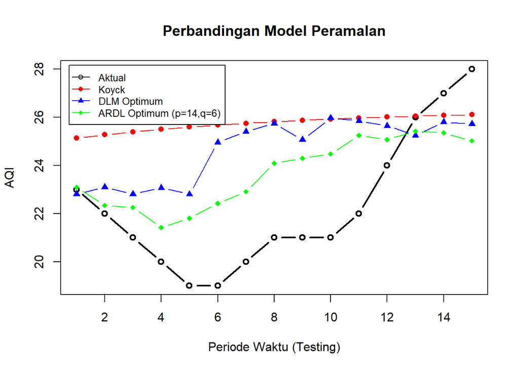

```r
par(mfrow=c(1,1))

idx <- 1:nrow(test)
y_range <- range(c(test$AQI, fore.koyck$forecasts, fore.dlm.opt$forecasts, fore.ardl$forecasts), na.rm = TRUE)

plot(idx, test$AQI, type="b", col="black", ylim=y_range, lwd=2,
     ylab="AQI", xlab="Periode Waktu (Testing)", main="Perbandingan Model Peramalan")

lines(idx, fore.koyck$forecasts, col="red", type="b", pch=16)
lines(idx, fore.dlm.opt$forecasts, col="blue", type="b", pch=17)
lines(idx, fore.ardl$forecasts, col="green", type="b", pch=18)

legend("topleft", legend=c("Aktual", "Koyck", "DLM Optimum", "ARDL Optimum (p=14,q=6)"),
       col=c("black","red","blue","green"), lty=1, pch=c(1,16,17,18), cex=0.8, inset=0.02)
```

**Interpretasi:** Dari plot terlihat garis ARDL (hijau) paling mendekati pola garis aktual (hitam) dibanding Koyck (merah) dan DLM Optimum (biru), sejalan dengan nilai MAPE dan deviance-nya yang paling kecil. Garis Koyck cenderung lebih landai/kurang responsif terhadap perubahan, mengindikasikan model ini kurang menangkap fluktuasi AQI dibanding dua model lainnya.